# Can trait patterns along gradients predict plant community responses to climate change?

John Guittar, Deborah Goldberg, Kari Klanderud, Richard Telford, Vigdis Vandvik

### Set working directory, load packages, create naming lists, load data

```r
# This R markdown file draws code from several other files
# 1) custom_functions.R:                My own custom functions
# 2) trait_data_processing.R:           Process and compile trait data for appropriate spp
# 3) bayesian_immigration_estimates.R:  Estimate immigration rates at each site
# 4) neutral_simulation.R:              The neutral simulation (based on set parameters)
# 5) simdat_processing_veg.R:           Determine Bray-Curtis distances between simulated turfs
# 6) simdat_processing_traits.R:        Determine trait-based distances between simulated turfs
# 7) simdat_spp.R:                      Determine species-specific deviations from neutral predictions

wd <- 'C:\\Users\\John\\Google Drive\\Documents\\michigan\\seedclim'
setwd(wd)

# load custom functions. Load MASS before dplyr because it takes over select()
source('MS_traitsTransplants/custom_functions.R')
```

```
##                                           Custom_Functions
## 1                  loadpax: install+load multiple packages
## 2                  cwm: calculate community weighted means
## 3                dist.fun: get distances among communities
## 4                 comp.fun: get distances to local control
## 5                         stat_sum_df: a plotting function
## 6                     stat_sum_single: a plotting function
## 7                                 fmt: a plotting function
## 8 process.comm: Calculates trait/veg distances to controls
## 9             probfixes: corrects taxonomic inconsitencies
```

```r
loadpax(pkg = c('Hmisc', 'ggplot2', 'reshape2', 'MASS', 'dplyr', 'data.table', 'grid', 'vegan', 'knitr',
  'gridExtra', 'tidyr'))
```

```
##      Hmisc    ggplot2   reshape2       MASS      dplyr data.table
##       TRUE       TRUE       TRUE       TRUE       TRUE       TRUE
##       grid      vegan      knitr  gridExtra      tidyr
##       TRUE       TRUE       TRUE       TRUE       TRUE
```

```r
# Trait names (left) and trait names for parsing for figure labels (right)
traits1 <- c(
  veg         = expression('Species'~'Composition'),
  leaf.area   = expression('Log Leaf Area ('*mm^2*')'),
  max.height  = expression('Log Max'~'Height (m)'),
  seed.mass   = expression('Log'~'Seed'~'Mass'~'(mg)'),
  sla         = expression('Log SLA ('*m^2*kg^-1*')'),
  buds        = expression('Bud'~'Number'),
  lat         = expression('Lateral'~'Spread'~'(%)'),
  offs        = expression('Offspring'~'(%)'),
  conper      = expression('Persistence'~'(%)')
)

# Trait names and full names
traits2 <- c(
  leaf.area   = 'Leaf Area',
  max.height  = 'Max. Height',
  seed.mass   = 'Seed Mass',
  sla         = 'SLA',
  buds        = 'Bud Number',
  lat         = 'Lat. Spread',
  offs        = 'Offspring',
  conper      = 'Persistence'
)

# trait list with veg
traits3 <- c(veg = 'Species Composition', traits2)

# Treatment and environmental variable names
treats <- c(TTC = 'Control', TT1 = 'Control', TT2 = 'Warmer', TT3 = 'Wetter', TT4 = 'Warmer+Wetter')

env.vars <- c(
  'SummerTemperature_gridded'   = expression('Summer Temperature ('*degree*'C)'),
  'Annualprecipitation_gridded' = expression('Annual'~'Precipitation (mm)')
)

#---------------------------------------------------------------------------------------------------

# Recalculate cover and trait data using MS Access? If so, you must be using 32-bit R
# source('trait_data_processing.R')

#---------------------------------------------------------------------------------------------------

# Load cover data, trait data, climate data
cover <- as.matrix(read.csv(row.names = 1, file = 'data\\cover.csv'))
cover.meta <- read.csv(file = 'data\\covermeta.csv')
trait.data.full <- read.csv(file = 'data\\traitdata.csv', stringsAsFactors = FALSE)
trait.data <- trait.data.full %>%
  dplyr::select(speciescode, leaf.area, max.height, seed.mass, sla, conper, offs, lat, buds) %>%
  rename(species = speciescode)
clim.years <- read.csv('data\\clim_years.csv')
clim.transplants <- read.csv(file = 'data\\clim_transplants.csv')
```

### Calculate CWMs, distances, turnover rates, immigration rates

```r
# CWMS
cwms <- data.frame(row.names = row.names(cover))
for (trait in names(traits2)) {
  cwms[, trait] = apply(cover, 1, cwm, trait = trait)
}

# A list of distance matrices
dists <- list()
for (trait in names(traits3)) {
  dists[[trait]] = dist.fun(cover, trait)
}

# Compare turf compositions to local controls, convert to data frame
comps = list()
for (trait in names(dists)) {
    comps[[trait]] = comp.fun(dists[[trait]], cover.meta, trait)
}
comps <- plyr::ldply(comps, .id = 'trait')

# --------------------------------------------------------------------------------------------------

# Calculate mean turnover rates in control turfs, by site. Control turfs only.
rates <- cbind(cover.meta[, c('turfID', 'Year', 'siteID')], cover)
rates <- rates[cover.meta$TTtreat %in% c('TTC', 'TT1'), ]

# Notes -- divide by 2 because there are
#  (1) 3 years of data and
#  (2) because every increase is presumably countered by a decrease
rates <- rates %>%
  melt(
    id.vars = c('siteID', 'turfID', 'Year'),
    variable.name = 'species', value.name = 'abun') %>%
  group_by(siteID, turfID, species) %>%
  summarise(turnover = abs(abun[Year == 2009] - abun[Year == 2011]) / 2 +
                       abs(abun[Year == 2011] - abun[Year == 2012]) +
                       abs(abun[Year == 2012] - abun[Year == 2013])) %>%
  select(-species) %>%
  group_by(siteID, turfID) %>%
  summarise(turnover = sum(turnover) / 3 / 2) %>%
  select(-turfID) %>%
  group_by(siteID) %>%
  summarise(turnover = mean(turnover))

# reset working directory for markdown...
setwd(wd)

# --------------------------------------------------------------------------------------------------

# Estimate immigration using bayesian / JAGS
# source("MS_TraitsTransplants\\bayesian_immigration_estimates.R")

# --------------------------------------------------------------------------------------------------

# load and combine turnover and immigration rates
m.bayes <- read.csv("data\\m.bayes.csv")

pars <- rates %>%
  transmute(
    site = siteID,
    d = round(turnover),
    m = signif(m.bayes$m[match(m.bayes$site, rates$siteID)], 3))

# --------------------------------------------------------------------------------------------------

# Run simulations? Edit script to change parameters
# e.g. to those in pars, or the general survey
# source("MS_TraitsTransplants\\neutral_simulation.R")

# --------------------------------------------------------------------------------------------------

# Process vegetation distances of simulation data?
# source("MS_TraitsTransplants\\simdat_processing_veg.R")

# --------------------------------------------------------------------------------------------------

# load sumulation data from a parameter survey
load("data\\simSummary_survey_veg.rda")

# --------------------------------------------------------------------------------------------------

# Process trait distances of simulations?
# source("simdat_processing_traits.R")

# --------------------------------------------------------------------------------------------------

# load simulation data
simdat.bayes <- read.csv('data\\simSummary_bayes_traits.csv', stringsAsFactors = FALSE)

# --------------------------------------------------------------------------------------------------

# Calculate deviations from neutral model by species * turf
# source('simdat_spp.R')

# --------------------------------------------------------------------------------------------------

# load deviations for single species * turf observations
load('data\\simdat_spp.rda')
```

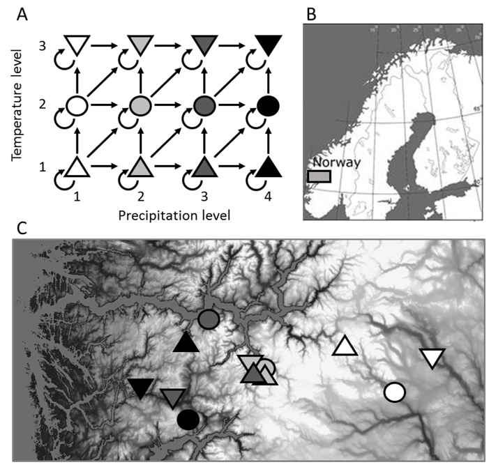

Figure1

#### **Figure 1.** Panel A: a schematic showing the orthogonal nature of climate variables across experimental sites, with black arrows representing the directions of turf transplants in replicates of five. Panels B and C show the geographical locations of experimental sites in Southern Norway. Symbol shapes and shadings reflect mean summer temperature level and mean annual precipitation level, respectively, in accordance with panel A.

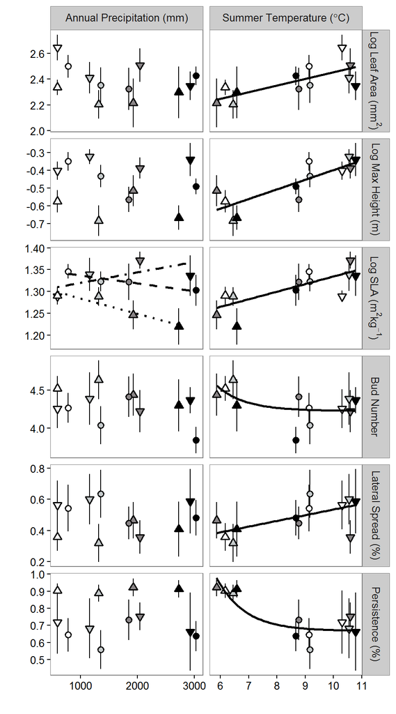

```r
# Figure 2

# combine CWM and metadata
x <- with(cover.meta,
  cbind(cwms,
    site = siteID,
    temp = SummerTemperature_gridded,
    precip = Annualprecipitation_gridded,
    temp.level   = Temperature_level,
    precip.level = Precipitation_level
  )[Year == 2009, ]
)

# summarise and calculate summary statistics
x <- x %>%
  melt(
    id.vars = c('site', 'temp', 'precip', 'temp.level', 'precip.level'),
    variable.name = 'trait',
    value.name = 'cwm') %>%
  group_by(trait, site, temp, precip, temp.level, precip.level) %>%
  summarise(
    len = length(temp),
    sd = sd(cwm),
    lower = quantile(cwm, 0.05),
    upper = quantile(cwm, 0.95),
    cwm = mean(cwm))

# multiple scaled temp and precip values to serve as an interaction variable predictor in the lm
tmp <- ungroup(x) %>%
  select(trait, cwm, temp, precip) %>%
  mutate(int = scale(temp, center = T, scale = F) * scale(precip, center = T, scale = F))

# make a list of models, with predictors in stepwise weighted regression determined by stepwise AIC
mods <- list()
for (i in unique(x$trait)) {
  tmp2 <- tmp[tmp$trait == i, names(tmp) != 'trait']
  mods[[i]] <- stepAIC(lm(cwm ~ ., data = tmp2, weight = x$len[x$trait == i]), trace = FALSE)
}

# fit more appropriate curves to connection persistence and bud number
for (i in c('conper', 'buds')) {
  mods[[i]] <- lm(cwm ~ exp(-temp), weight = x$len[x$trait == i], data = tmp[tmp$trait == i, ])
}

# fix scientific notation, create table of model details
options(scipen = 20)
tats <- plyr::ldply(mods, function(x) data.frame(
  variable = row.names(coef(summary(x))), coef(summary(x))))
tats <- tats %>%
  select(trait = .id, variable, Estimate, SE = `Std..Error`, t.value, p.value = `Pr...t..`) %>%
  filter(variable != '(Intercept)')
tats.full <- tats
tats <- filter(tats, p.value < 0.05)

# Define short list of significant traits, for use in later figures
shortlist <- c('veg', as.character(unique(tats$trait)))

# Filter df for significant relationships, reformat, cleanup
x <- x %>%
  filter(trait %in% tats$trait) %>%
  gather(variable, value, temp, precip) %>%
  mutate(
    trait.label = factor(traits1[match(trait, names(traits1))], levels = traits1),
    variable.label = as.character(ifelse(variable == 'temp', env.vars[1], env.vars[2])))

tats$variable.label <- ifelse(tats$variable == 'temp', as.character(env.vars[1]),
  paste0(as.character(env.vars[2])))

x$lty <- ifelse(x$trait == 'sla' & x$variable == 'precip', x$temp.level + 1, 1)

# Plot
fig2 <- ggplot(x, aes(x = value, y = cwm, group = 1, weight = len, fill = factor(precip.level), lty = factor(lty), shape = factor(temp.level))) +
  geom_point() +
  scale_shape_manual(values = c(24,21,25)) +
  scale_linetype_manual(values = c('solid','dotted','dashed','dotdash')) +
  scale_fill_manual(values = c("#FFFFFF", "#C6CBCC", "#8A8587", "#000000")) +
  geom_pointrange(aes(ymin = cwm - sd, ymax = cwm + sd), lty = 1) +
  facet_grid(trait.label ~ variable.label, scales = 'free', labeller = label_parsed) +
  stat_smooth(method = 'lm', formula = y ~ exp(-x), se = FALSE, color = 'black',
    data = filter(x, trait  %in% c('conper', 'buds') & variable == 'temp')) +
  stat_smooth(method = 'lm', se = FALSE, color = 'black', data = filter(x, trait %in% c('leaf.area', 'max.height', 'lat', 'sla') & variable == 'temp')) +
  stat_smooth(aes(group = factor(lty)), method = 'lm', se = FALSE, color = 'black', data = filter(x, trait == 'sla' & variable == 'precip'))  +
  labs(x = '', y = '') +
  theme_bw() +
  theme(
    legend.position  = 'none',
    panel.grid.minor = element_blank(),
    panel.grid.major = element_blank())

fig2
```

```r
# Table 1

tmp <- tats.full %>%
  rename("Trait" = trait, "t-statistic" = t.value, "p-value" = p.value, "Trait" = trait,
    "Variable" = variable) %>%
  mutate(
    Trait = traits3[match(Trait, names(traits3))],
    Variable = c('Temp', 'Precip', 'exp(-Temp)', 'Temp x Precip')[match(Variable, c('temp', 'precip', 'exp(-temp)', 'int'))],
    variable.label = NULL) %>%
  arrange(Trait)

tmp[, 3:5] <- apply(tmp[, 3:5], 2, function(x) format(round(as.numeric(x), 2), nsmall = 2))
#tmp$"p-value" <- ifelse(tmp$"p-value" > 0.05, 'NS', ifelse(tmp$"p-value" < 0.001, '< 0.001', format(round(tmp$"p-value", 3), 3)))
tmp[tmp$"p-value" == 'NS', c('Estimate', 'SE', 't-statistic')] <- ''
tmp[tmp$Estimate == "  0.00", c('Estimate', 'SE')] <- '< 0.01'
tmp$Trait[!1:nrow(tmp) %in% match(unique(tmp$Trait), tmp$Trait)] <- ''

kable(tmp, align = 'r')
```

| Trait | Variable | Estimate | SE | t-statistic | p-value |
| --- | --- | --- | --- | --- | --- |
| Bud Number | exp(-Temp) | 118.15 | 52.83 | 2.24 | 0.0492866 |
| Lat. Spread | Temp | 0.04 | 0.01 | 2.50 | 0.0313523 |
| Leaf Area | Temp | 0.05 | 0.01 | 3.83 | 0.0040462 |
|  | Precip | < 0.01 | < 0.01 | -1.50 | 0.1676392 |
| Max. Height | Temp | 0.05 | 0.01 | 4.26 | 0.0016537 |
| Offspring | Temp x Precip | < 0.01 | < 0.01 | -1.69 | 0.1226384 |
| Persistence | exp(-Temp) | 109.14 | 19.28 | 5.66 | 0.0002092 |
| SLA | Temp | 0.02 | 0.00 | 5.35 | 0.0006831 |
|  | Precip | < 0.01 | < 0.01 | -1.24 | 0.2512745 |
|  | Temp x Precip | < 0.01 | < 0.01 | 2.48 | 0.0380277 |

#### **Table 1.** Summary statistics for the best-fit weighted linear model for each trait using mean summer temperature, annual precipitation, and their interaction as potential predictor variables, weighted by the sample size at each site (N = 10-25). Best-fit models were determined using AIC values. For bud number and connection persistence, exponentially transforming the temperature axis resulted in better model fit. Site trait means and significant regressions are shown in Figure 2.

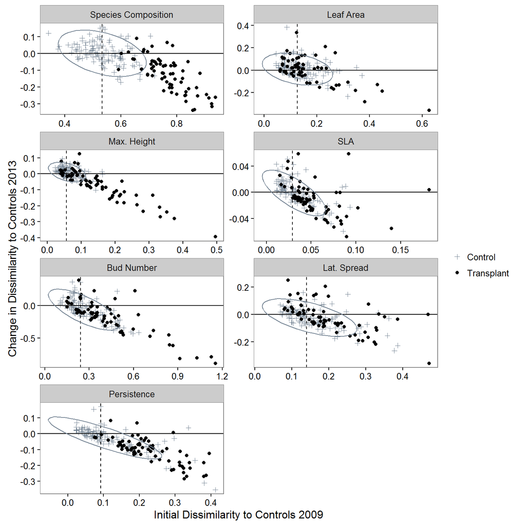

```r
# Figure 3

x <- comps %>%
  filter(
    year %in% c(2009, 2013) &
    turfID %in% cover.meta$turfID[cover.meta$TTtreat != 'TT3'] &
    trait %in% shortlist) %>%
  mutate(
    trait = factor(traits3[match(trait, names(traits3))], traits3),
    treat = cover.meta$TTtreat[match(turfID, cover.meta$turfID)],
    treat = factor(treats[match(treat, names(treats))], unique(treats)),
    treat.group = factor(ifelse(treat == 'Control', 'Control', 'Transplant')))

x <- dcast(x, trait + treat.group + turfID + treat ~ paste0('dist', year), value.var = 'dist.tt1')

# determine dashed barrier
vlines <- x %>%
  filter(treat.group == 'Control') %>%
  group_by(trait) %>%
  summarise(vline = quantile(dist2009, 0.5))

# Plot
fig3 <- ggplot(x, aes(x = dist2009, y = dist2013 - dist2009, color = treat.group, shape = treat.group)) +
  theme_bw() +
  scale_color_manual(values = c('slategrey', 'black'), name = '') +
  scale_shape_manual(values=c(3,16), name='') +
  theme(
    panel.grid.minor = element_blank(),
    panel.grid.major = element_blank(),
    legend.key       = element_blank()) +
  geom_point(size = 1.5, data = subset(x, treat.group == 'Control')) +
  geom_point(size = 1.5, data = subset(x, treat.group != 'Control')) +
  facet_wrap(~ trait, ncol = 2, scales = 'free') +
  geom_vline(aes(xintercept = vline), vlines, lty = 2) +
  geom_hline(yintercept = 0) +
  labs(x = 'Initial Dissimilarity to Controls 2009', y = 'Change in Dissimilarity to Controls 2013') +
  stat_ellipse(data = subset(x, treat.group == 'Control'), show.legend = FALSE)

fig3
```

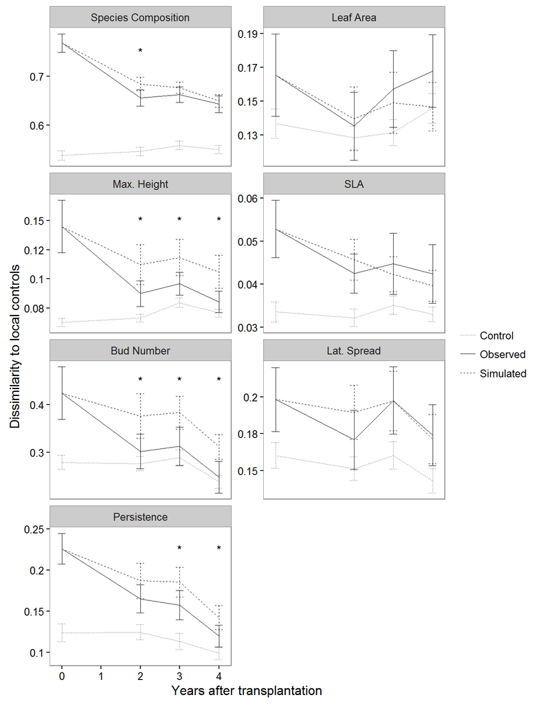

```r
# Figure 4

# Combine observed and simulated data sets
x <- rbind(simdat.bayes, mutate(comps, m = 'field', d = 'field'))

# select traits and cleanup
x <- x %>%
  filter(trait %in% shortlist) %>%
  mutate(
    treat = cover.meta$TTtreat[match(turfID, cover.meta$turfID)],
    treat = factor(treats[match(treat, names(treats))], unique(treats)),
    year = as.numeric(year) - 2009,
    m.group = factor(ifelse(m == 'field', 'Observed', 'Simulated')))

# remove wetter-transplants and group everything into warmer category
x <- filter(x, treat != 'Wetter') %>%
     mutate(treat = factor(ifelse(treat == 'Control', 'Control', 'Warmer'), c('Control', 'Warmer')))

# Run t.tests to determine if observed turfs significantly differant than simulated
stats <- x %>%
  filter(treat != 'Control') %>%
  group_by(trait, year, treat) %>%
  do(mod  = t.test(dist.tt1 ~ m.group, data = .)) %>%
  mutate(p = mod$p.value, m.group = 'Observed', mod = NULL)

# Manually specify maximum y values for plotting significance symbols
sigtraits <- unique(filter(stats, p < 0.05)$trait)
stats$y <- NA
stats$y <- c(0.45, 0.225, 0.15, 0.75)[match(stats$trait, sigtraits)]

# Remove control column, replace with horizontal lines which represent controls anyway, fix labels
x <- x %>%
  mutate(
    m.group = ifelse(treat == 'Control', 'Control', as.character(m.group)),
    treat = 'Warmer')

# Fix labels
x$trait <- factor(traits3[match(x$trait, names(traits3))], levels = traits3)
stats$trait <- factor(traits3[match(stats$trait, names(traits3))], levels = traits3)

fig4 <- ggplot(x, aes(x = year, y = dist.tt1, lty = m.group)) +
  stat_sum_df('mean_cl_normal', geom = 'errorbar', size = 0.3) +
  stat_sum_single(mean, geom = 'line', size = 0.3) +
  facet_wrap(~ trait, scales = 'free_y', ncol = 2) +
  theme_bw() +
  theme(
    panel.grid.major = element_blank(),
    panel.grid.minor = element_blank(),
    legend.key = element_blank()) +
  labs(x = 'Years after transplantation',
       y = 'Dissimilarity to local controls') +
  scale_linetype_manual(values = c(3,1,2), name = '') +
  scale_y_continuous(labels = fmt())

tmp <- subset(stats, p < 0.05)
if (nrow(tmp) > 0) {
  fig4 <- fig4 + geom_text(aes(x = year, y = y, lty = NA), data = tmp, color = 'black', label = '*')
}

fig4
```

#### **Figure 4.** Mean trait dissimilarities of turf communities to local controls from 2009 to 2013. Solid lines represent observed field data; dashed lines represent simulated null expectations based on 100 null model simulation runs; dotted lines represent the mean dissimilarity among control turfs within sites. Null model simulations use immigration rates estimated by fitting our model of trait-neutral community dynamics to observed control turf community dynamics using a Bayesian approach. Error bars show 95% confidence intervals. Statistical differences between observed and simulated community weighted means are shown when p < 0.05 (*).

```r
## Table S1
x <- trait.data[, names(traits2)]

# calculate N
apply(x, 2, function(x) length(x[!is.na(x)]))
```

```
##  leaf.area max.height  seed.mass        sla       buds        lat
##        142        166        145        152        150        143
##       offs     conper
##        140        142
```

```r
names(x) <- traits3[match(names(x), names(traits3))]
x <- cor(x, use = 'complete.obs')
tmp <- format(round(x, 2), nsmall = 2)
for (i in 1:ncol(tmp)) tmp[i:nrow(tmp), i] <- ''
tmp <- tmp[-nrow(tmp), -1]
kable(tmp, align = 'r')
```

|  | Max. Height | Seed Mass | SLA | Bud Number | Lat. Spread | Offspring | Persistence |
| --- | --- | --- | --- | --- | --- | --- | --- |
| Leaf Area | 0.46 | 0.51 | 0.34 | -0.13 | -0.12 | -0.11 | -0.03 |
| Max. Height |  | 0.33 | 0.17 | 0.15 | -0.02 | -0.01 | 0.18 |
| Seed Mass |  |  | 0.16 | 0.06 | -0.12 | 0.05 | 0.16 |
| SLA |  |  |  | -0.36 | -0.14 | 0.11 | -0.40 |
| Bud Number |  |  |  |  | 0.30 | 0.00 | 0.30 |
| Lat. Spread |  |  |  |  |  | 0.16 | -0.08 |
| Offspring |  |  |  |  |  |  | -0.12 |

```r
# p values
tmp <- rcorr(x)$P %>%
  melt() %>%
  filter(value < 0.05) %>%
  rename(trait1 = Var1, trait2 = Var2, p = value)
tmp <- tmp[match(unique(tmp$p), tmp$p), ]
mutate(tmp, p = signif(p, 2))
```

```
##        trait1 trait2     p
## 1  Bud Number    SLA 0.011
## 2 Persistence    SLA 0.030
```

Significant (p < 0.05) Pearson correlations in species trait values.

```r
# Table S2
x <- cwms[cover.meta$Year == 2009, ]

# calculate N
apply(x, 2, function(x) length(x[!is.na(x)]))
```

```
##  leaf.area max.height  seed.mass        sla       buds        lat
##        232        232        232        232        232        232
##       offs     conper
##        232        232
```

```r
names(x) <- traits3[match(names(x), names(traits3))]
x <- cor(x)
tmp <- format(round(x, 2), 2)
for (i in 1:ncol(tmp)) { tmp[i:nrow(tmp), i] <- '' }
tmp <- tmp[-nrow(tmp), -1]

kable(tmp, align = 'r')
```

|  | Max. Height | Seed Mass | SLA | Bud Number | Lat. Spread | Offspring | Persistence |
| --- | --- | --- | --- | --- | --- | --- | --- |
| Leaf Area | 0.52 | 0.32 | 0.31 | -0.31 | 0.17 | 0.11 | -0.28 |
| Max. Height |  | -0.08 | 0.48 | -0.17 | 0.55 | 0.35 | -0.37 |
| Seed Mass |  |  | -0.02 | -0.15 | -0.50 | 0.09 | 0.10 |
| SLA |  |  |  | -0.12 | 0.11 | 0.15 | -0.47 |
| Bud Number |  |  |  |  | -0.17 | -0.10 | 0.64 |
| Lat. Spread |  |  |  |  |  | 0.35 | -0.35 |
| Offspring |  |  |  |  |  |  | -0.15 |

#### **Table S2** Pearson correlations in community weighted means. N = 232.

```r
# p values
tmp <- rcorr(x, type = 'pearson')$P %>%
  melt() %>%
  filter(value < 0.05) %>%
  rename(trait1 = Var1, trait2 = Var2, pval = value)
tmp <- tmp[match(unique(tmp$pval), tmp$pval), ]
mutate(tmp, pval = signif(pval, 2))
```

```
##        trait1      trait2   pval
## 1  Bud Number   Leaf Area 0.0120
## 2 Persistence   Leaf Area 0.0390
## 3         SLA Max. Height 0.0380
## 4  Bud Number Max. Height 0.0410
## 5 Lat. Spread Max. Height 0.0210
## 6 Persistence Max. Height 0.0036
## 7 Lat. Spread   Seed Mass 0.0440
## 8 Persistence         SLA 0.0092
## 9 Persistence  Bud Number 0.0052
```

Significant (p < 0.05) Pearson correlations in community weighted means.

```r
# Table S3
tmp <- filter(cover.meta, TTtreat == 'TTC')

pars.table <- pars %>%
  mutate(
    m       = as.numeric(substr(as.character(signif(pars$m[match(site, pars$site)], 3)), 1, 4)),
    temp    = round(tmp$SummerTemperature_gridded[match(site, tmp$siteID)], 2),
    precip  = round(tmp$Annualprecipitation_gridded[match(site, tmp$siteID)], 0),
    ordr    = as.integer(paste0(tmp$Temperature_level, tmp$Precipitation_level)[match(site, tmp$siteID)])) %>%
  ungroup() %>%
  arrange(ordr) %>%
  select("Site" = site, 'Summer Temperature (C)' = temp, 'Annual Precipitation (mm)' = precip, d, m)
kable(pars.table, align = 'r')
```

| Site | Summer Temperature (C) | Annual Precipitation (mm) | d | m |
| --- | --- | --- | --- | --- |
| Ulvhaugen | 6.17 | 596 | 31 | 0.06 |
| Lavisdalen | 6.45 | 1321 | 23 | 0.16 |
| Gudmedalen | 5.87 | 1925 | 26 | 0.28 |
| Skjellingahaugen | 6.58 | 2725 | 20 | 0.32 |
| Alrust | 9.14 | 789 | 34 | 0.26 |
| Hogsete | 9.17 | 1356 | 31 | 0.35 |
| Rambera | 8.77 | 1848 | 24 | 0.29 |
| Veskre | 8.67 | 3029 | 32 | 0.39 |
| Fauske | 10.30 | 600 | 37 | 0.17 |
| Vikesland | 10.55 | 1161 | 36 | 0.17 |
| Arhelleren | 10.60 | 2044 | 33 | 0.15 |
| Ovstedal | 10.78 | 2923 | 22 | 0.17 |

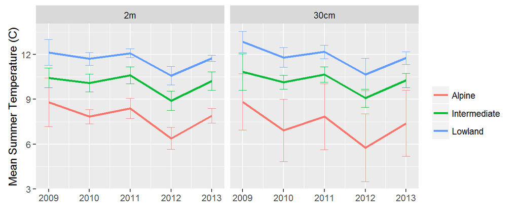

```r
# Figure S1
figS1 <- ggplot(clim.years, aes(x = year, y = temp, color = tempLevel)) +
  stat_sum_df('mean_cl_normal', geom = 'errorbar', size = 0.3) +
  stat_sum_single(mean, geom = 'line', size = 1) +
  facet_wrap(~loc) +
  scale_color_discrete(name = '') +
  labs(x = '', y = "Mean Summer Temperature (C)")

figS1
```